# 📊 Fase 01: Análisis Exploratorio de Datos (EDA) y Preprocesamiento

**Objetivo del Notebook:** Este cuaderno constituye la fase inicial del ciclo de vida del modelo de *Machine Learning*. Su propósito fundamental es cargar, auditar y preparar el dataset sintético de defectos industriales para garantizar que las Redes Neuronales Convolucionales (CNN) puedan asimilar la información de forma óptima y sin sesgos durante el entrenamiento.

**Flujo de ejecución (*Pipeline*):**

1. **Configuración y Carga de Datos:** Inicialización del entorno TensorFlow e indexación de las imágenes distribuidas en las clases de entrenamiento y validación (*Crack, Hole, Normal, Rust, Scratch*).
2. **Análisis Exploratorio de Datos (EDA):** Verificación matemática del balanceo de clases para evitar colapsos del modelo hacia la clase mayoritaria y análisis de la densidad lumínica (histogramas de píxeles) para comprender la varianza de textura del metal.
3. **Pipeline de Preprocesamiento (*Data Augmentation*):** Diseño de un motor de aumento de datos dinámico (*DataGenerator*). Se aplican transformaciones afines (rotaciones, volteos y variaciones de zoom) con el objetivo de dotar a las futuras redes de invarianza espacial y prevenir el sobreajuste (*overfitting*).

```python
import os
import warnings
import logging

# Variables de entorno
os.environ['TF_CPP_MIN_LOG_LEVEL'] = '3'
os.environ['TF_ENABLE_ONEDNN_OPTS'] = '0'
warnings.filterwarnings('ignore')

# Importaciones base para EDA y Carga
import tensorflow as tf
import numpy as np
import pandas as pd
import matplotlib.pyplot as plt
import seaborn as sns
from PIL import Image

# Silenciadores internos
tf.get_logger().setLevel(logging.ERROR)
tf.autograph.set_verbosity(3)

# Configuración visual profesional para el TFM
sns.set_theme(style="whitegrid")
plt.rcParams.update({'font.size': 11, 'axes.labelsize': 12, 'axes.titlesize': 14})

# ==========================================
# Definición de rutas relativas (Multiplataforma)
# ==========================================
# Como los notebooks están en la carpeta 'notebooks/',
# usamos '..' para subir a la raíz del proyecto y luego entramos en 'data'
DATA_DIR = os.path.join("..", "data", "industrial_defect_dataset")

TRAIN_DIR = os.path.join(DATA_DIR, "train")
VAL_DIR = os.path.join(DATA_DIR, "val")
META_CSV = os.path.join(DATA_DIR, "metadata.csv")

BATCH_SIZE = 32
IMG_HEIGHT = 224
IMG_WIDTH = 224

print(f"Versión de TensorFlow: {tf.__version__}")
print("Entorno de datos configurado correctamente.")
```

```
Versión de TensorFlow: 2.21.0
Entorno de datos configurado correctamente.
```

```python
# ==========================================
# BLOQUE 2: AUDITORÍA E INTEGRIDAD (SANITY CHECK)
# ==========================================
print("\n--- Iniciando Sanity Check del Dataset ---")
imagenes_corruptas = 0
dimensiones_originales = set()
clases_locales = os.listdir(TRAIN_DIR)

for clase in clases_locales:
    ruta_clase = os.path.join(TRAIN_DIR, clase)
    if os.path.isdir(ruta_clase):
        archivos = os.listdir(ruta_clase)
        for archivo in archivos[:500]: # Escaneamos una muestra amplia por seguridad
            img_path = os.path.join(ruta_clase, archivo)
            try:
                with Image.open(img_path) as img:
                    img.verify()
                    dimensiones_originales.add(img.size)
            except (IOError, SyntaxError):
                imagenes_corruptas += 1

print(f"Imágenes corruptas detectadas: {imagenes_corruptas}")
print(f"Dimensiones originales en disco: {dimensiones_originales}")
if imagenes_corruptas == 0:
    print("✓ Confirmado: Dataset libre de archivos corruptos.")
```

```
--- Iniciando Sanity Check del Dataset ---
Imágenes corruptas detectadas: 0
Dimensiones originales en disco: {(256, 256)}
✓ Confirmado: Dataset libre de archivos corruptos.
```

```python
# ==========================================
# BLOQUE 3: CARGA DE TENSORES EN MEMORIA
# ==========================================
print("\n--- Cargando Datos de Entrenamiento (80%) ---")
train_dataset = tf.keras.utils.image_dataset_from_directory(
    TRAIN_DIR,
    color_mode='grayscale',
    image_size=(IMG_HEIGHT, IMG_WIDTH),
    batch_size=BATCH_SIZE,
    shuffle=True,
    seed=42
)

print("\n--- Cargando Datos de Validación (20%) ---")
val_dataset = tf.keras.utils.image_dataset_from_directory(
    VAL_DIR,
    color_mode='grayscale',
    image_size=(IMG_HEIGHT, IMG_WIDTH),
    batch_size=BATCH_SIZE,
    shuffle=False
)

class_names = train_dataset.class_names
print(f"Clases registradas por Keras: {class_names}")
```

```
--- Cargando Datos de Entrenamiento (80%) ---
Found 12000 files belonging to 5 classes.

--- Cargando Datos de Validación (20%) ---
Found 3000 files belonging to 5 classes.
Clases registradas por Keras: ['crack', 'hole', 'normal', 'rust', 'scratch']
```

```
--- Tabla resumen para la Memoria del TFM ---
Conjunto  Entrenamiento (80%)  Validación (20%)  Total
Clase
crack                    2400               600   3000
hole                     2400               600   3000
normal                   2400               600   3000
rust                     2400               600   3000
scratch                  2400               600   3000
```

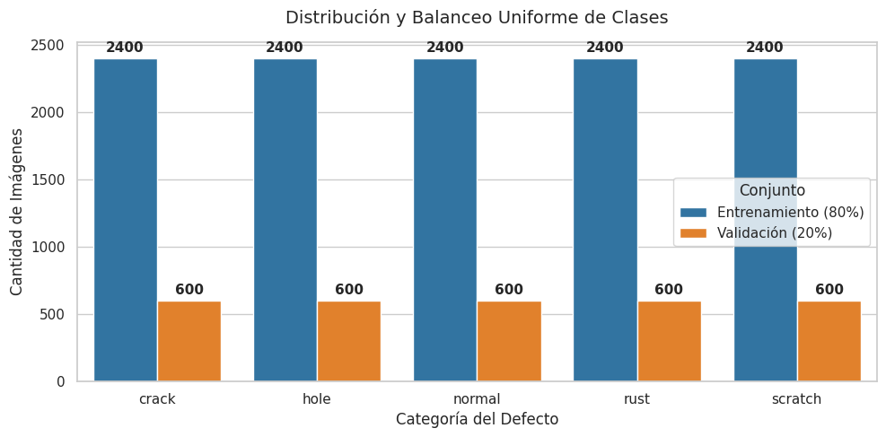

```python
# ==========================================
# BLOQUE 4: ANÁLISIS DE BALANCEO Y VOLUMEN
# ==========================================
def contar_imagenes(directorio, nombre_conjunto):
    conteo = []
    for clase in class_names:
        ruta_clase = os.path.join(directorio, clase)
        if os.path.exists(ruta_clase):
            num_imagenes = len(os.listdir(ruta_clase))
            conteo.append({'Clase': clase, 'Cantidad': num_imagenes, 'Conjunto': nombre_conjunto})
    return conteo

df_balanceo = pd.DataFrame(contar_imagenes(TRAIN_DIR, 'Entrenamiento (80%)') + contar_imagenes(VAL_DIR, 'Validación (20%)'))

print("\n--- Tabla resumen para la Memoria del TFM ---")
tabla_pivote = df_balanceo.pivot(index='Clase', columns='Conjunto', values='Cantidad')
tabla_pivote['Total'] = tabla_pivote['Entrenamiento (80%)'] + tabla_pivote['Validación (20%)']
print(tabla_pivote)

# Gráfico de balanceo
plt.figure(figsize=(10, 5))
grafico_barras = sns.barplot(data=df_balanceo, x='Clase', y='Cantidad', hue='Conjunto', palette=['#1f77b4', '#ff7f0e'])
for container in grafico_barras.containers:
    grafico_barras.bar_label(container, padding=3, fontweight='bold')
plt.title('Distribución y Balanceo Uniforme de Clases', pad=15)
plt.xlabel('Categoría del Defecto')
plt.ylabel('Cantidad de Imágenes')
plt.tight_layout()
plt.show()
```

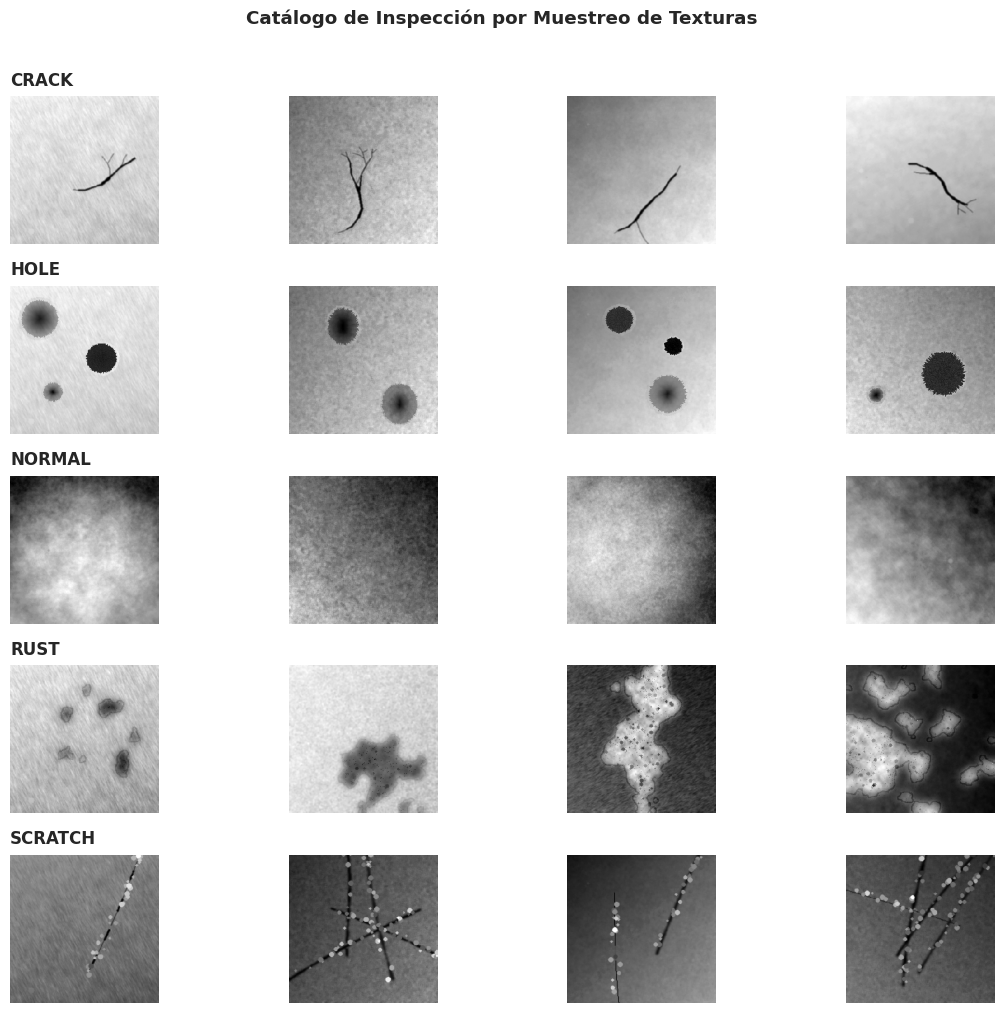

```python
# ==========================================
# BLOQUE 5: CATÁLOGO VISUAL ESTRUCTURADO
# ==========================================
fig, axes = plt.subplots(nrows=len(class_names), ncols=4, figsize=(12, 10))
fig.suptitle('Catálogo de Inspección por Muestreo de Texturas', fontweight='bold', y=1.01)

for i, class_name in enumerate(class_names):
    ruta_clase = os.path.join(TRAIN_DIR, class_name)
    archivos = os.listdir(ruta_clase)[:4]
    for j, archivo in enumerate(archivos):
        img_path = os.path.join(ruta_clase, archivo)
        img = tf.keras.utils.load_img(img_path, color_mode="grayscale", target_size=(IMG_HEIGHT, IMG_WIDTH))
        axes[i, j].imshow(img, cmap='gray')
        axes[i, j].axis('off')
        if j == 0:
            axes[i, j].set_title(class_name.upper(), fontsize=12, fontweight='bold', loc='left', pad=8)

plt.tight_layout()
plt.show()
```

```
--- Calculando distribución estadística de píxeles ---
```

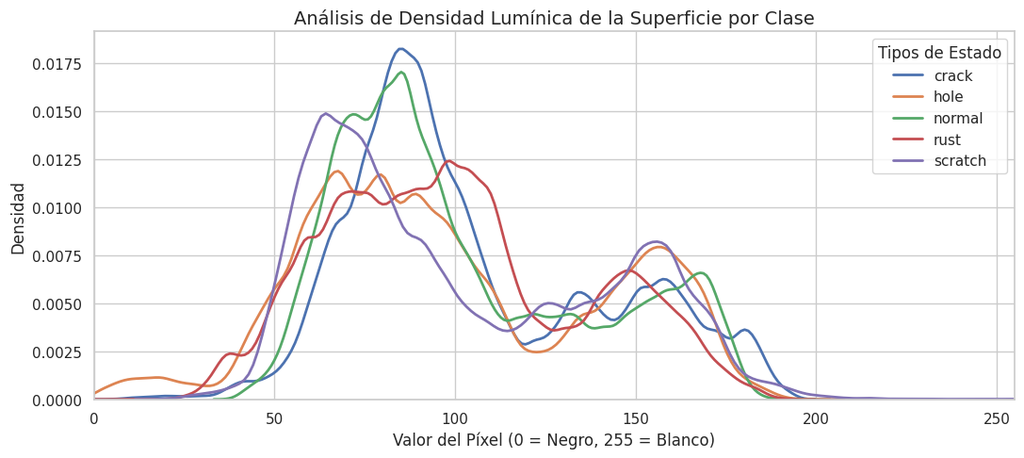

```python
# ==========================================
# BLOQUE 6: HISTOGRAMA DE INTENSIDAD DE PÍXELES
# ==========================================
plt.figure(figsize=(11, 5))
print("\n--- Calculando distribución estadística de píxeles ---")

for class_name in class_names:
    ruta_clase = os.path.join(TRAIN_DIR, class_name)
    archivos = os.listdir(ruta_clase)[:30] # Muestra estadística representativa
    valores_pixeles = []
    for archivo in archivos:
        img_path = os.path.join(ruta_clase, archivo)
        img_array = tf.keras.utils.img_to_array(tf.keras.utils.load_img(img_path, color_mode="grayscale"))
        valores_pixeles.extend(img_array.flatten())
    sns.kdeplot(valores_pixeles, label=class_name, linewidth=2)

plt.title('Análisis de Densidad Lumínica de la Superficie por Clase')
plt.xlabel('Valor del Píxel (0 = Negro, 255 = Blanco)')
plt.ylabel('Densidad')
plt.xlim(0, 255)
plt.legend(title='Tipos de Estado')
plt.tight_layout()
plt.show()
```